# Das Stimmungsbild zu Michael Jordan auf YouTube – eine quantitative Textanalyse

## 3. Deskriptive Analyse

### Kommentaranzahl

In diesem Kapitel beschäftige ich mich zunächst mit der generellen Aktivität im Kommentarbereich der untersuchten Videos und betrachte dafür die Anzahl der Kommentare. Insgesamt umfasst der Datensatz 68.877 Kommentare.

```r
nrow(mj_data_filtered)
```

```
## [1] 68877
```

Aufgeteilt auf die Videos sieht das so aus:

```
## # A tibble: 4 × 2
##   source  n_comments
##   <chr>        <int>
## 1 video_1      24811
## 2 video_2      24875
## 3 video_3      12972
## 4 video_4       6219
```

Um die Entwicklung der Kommentaranzahl über die Zeit zu analysieren, bietet sich eine monatliche Aggregation der Kommentare an.

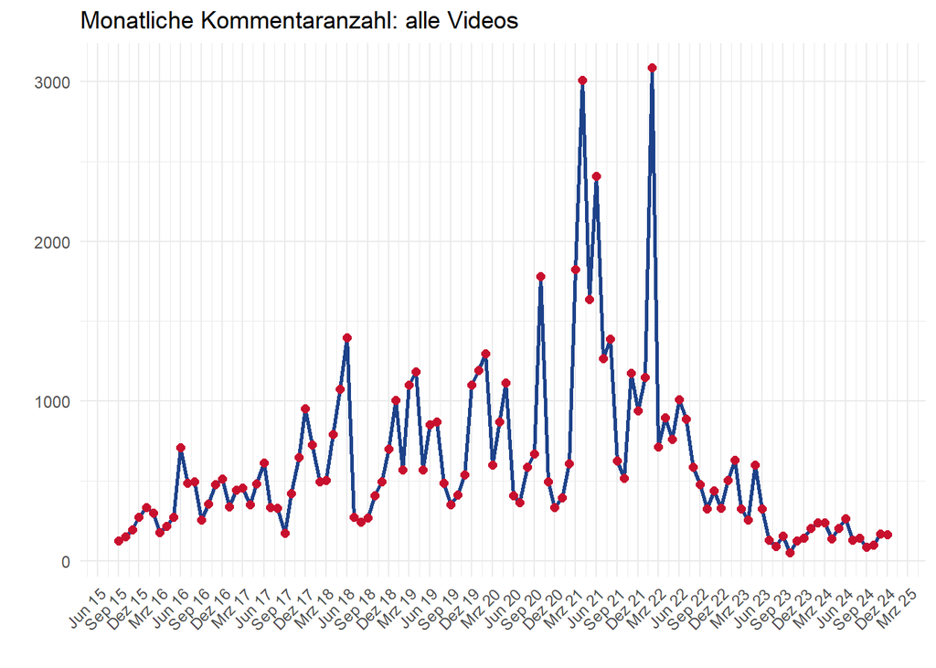

```r
# lubridate-Paket rundet auf Monatsanfang
comments_month <- mj_data_filtered %>%
  mutate(month = floor_date(date, "month")) %>%
  group_by(month) %>%
  summarise(n_comments = n())

ggplot(comments_month, aes(x = month, y = n_comments)) +
  geom_line(color = "#1D428A", size = 1) + # NBA Blue
  geom_point(color = "#C8102E", size = 2) + # NBA Red
  scale_x_date(
    date_breaks = "3 months",
    date_labels = "%b %y") +
  labs(title = "Monatliche Kommentaranzahl: alle Videos",
       x = "",
       y = "") +
  theme_minimal() +
  theme(axis.text.x = element_text(angle = 45, hjust = 1))
```

Die Grafik zeigt die Kommentaranzahl für jeden Monat des gewählten Zeitraums (September 2015 bis Dezember 2024). Vor allem zwei Peaks stechen ins Auge: der erste im April 2021 und der zweite im Februar 2022. Eine inhaltliche Erklärung für diese erhöhten Kommentaraktivitäten gibt es auf den ersten Blick nicht; zumindest sind keine besonderen Ereignisse rund um Michael Jordan bekannt, die diese Ausreißer erklären könnten.

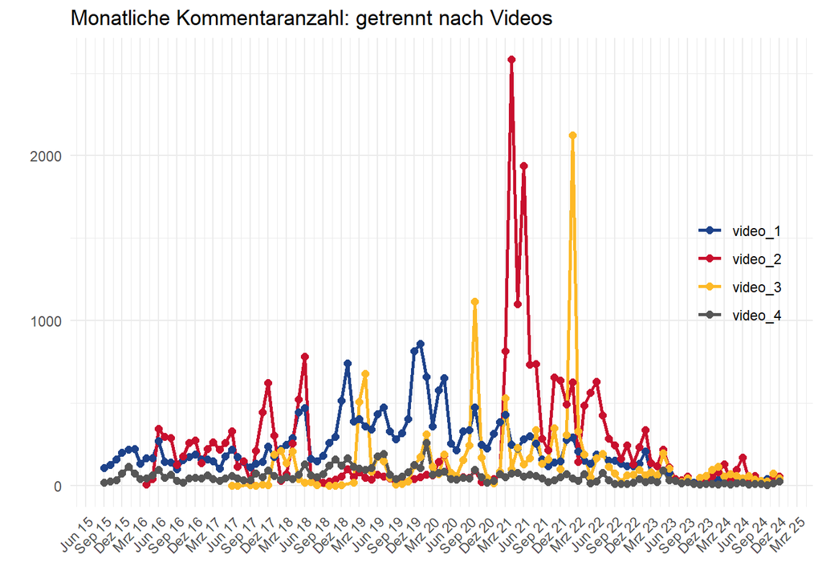

```r
comments_month_by_video <- mj_data_filtered %>%
  mutate(month = floor_date(date, "month")) %>%
  group_by(source, month) %>%
  summarise(n_comments = n(), .groups = "drop")

ggplot(comments_month_by_video, aes(x = month, y = n_comments, color = source)) +
  geom_line(size = 1) +
  geom_point(size = 2) +
  scale_x_date(date_breaks = "3 months", date_labels = "%b %y") +
  scale_color_manual(name = NULL, values = c(
    "video_1" = "#1D428A",   # NBA Blue
    "video_2" = "#C8102E",   # NBA Red
    "video_3" = "#FDB927",   # Gold
    "video_4" = "#565656"    # Dunkelgrau
    )) +
  labs(title = "Monatliche Kommentaranzahl: getrennt nach Videos",
       x = "",
       y = "") +
  theme_minimal() +
  theme(axis.text.x = element_text(angle = 45, hjust = 1),
        legend.position = c(0.9, 0.5),
     legend.position.inside = TRUE)
```

Klarheit bringt ein Blick auf den Zeitverlauf der einzelnen Videos. Die Peaks im Jahr 2021 und 2022 sind jeweils auf Video 2 und Video 3 zurückzuführen. Video 2 wurde im April 2021 besonders häufig kommentiert (und vermutlich auch angeschaut), Video 3 im Februar 2022. Eine plausible Erklärung dafür sind algorithmische Effekte von YouTube: Wenn Videos häufiger angesehen und stärker interaktiv genutzt werden, führt dies zu einer vermehrten Empfehlung durch den YouTube-Algorithmus, was wiederum zu weiteren Aufrufen und Kommentaren führt.

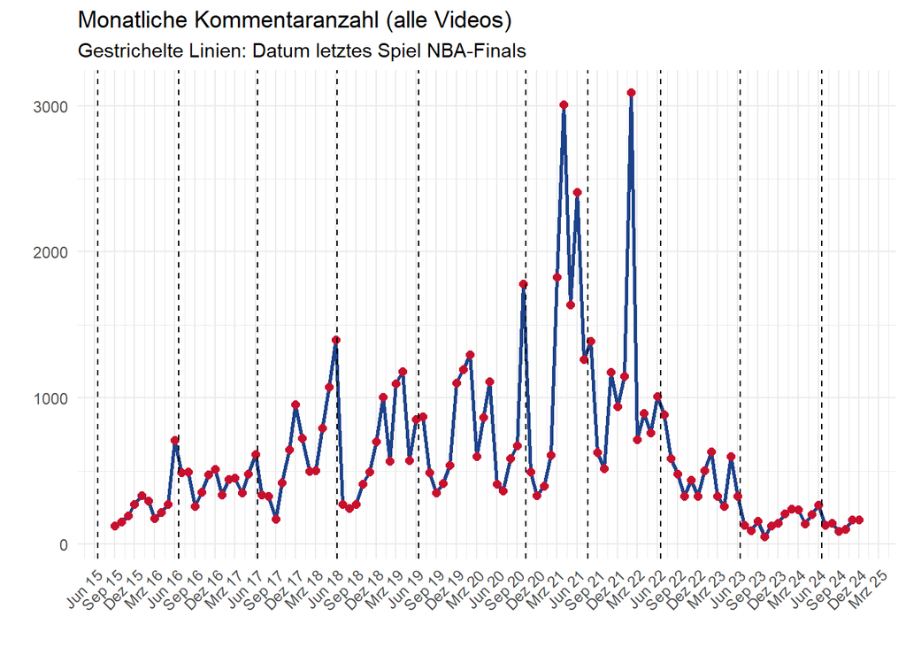

```r
finals <- data.frame(
  date_finals = as.Date(c("2015-06-16", "2016-06-19", "2017-06-12", "2018-06-08",
                   "2019-06-13", "2020-10-11", "2021-07-20", "2022-06-16",
                   "2023-06-12", "2024-06-17")),
  season = c("2014/15", "2015/16", "2016/17", "2017/18",
             "2018/19", "2019/20", "2020/21", "2021/22",
             "2022/23", "2023/24")
)


ggplot(comments_month, aes(x = month, y = n_comments)) +
  geom_line(color = "#1D428A", size = 1) +  # NBA Blue
  geom_point(color = "#C8102E", size = 2) + # NBA Red
  scale_x_date(date_breaks = "3 months", date_labels = "%b %y") +
  labs(title = "Monatliche Kommentaranzahl (alle Videos)",
       subtitle = "Gestrichelte Linien: Datum letztes Spiel NBA-Finals",
       x = "",
       y = "") +
  theme_minimal() +
  theme(axis.text.x = element_text(angle = 45, hjust = 1)) +
  geom_vline(
    data = finals,
    aes(xintercept = as.numeric(date_finals)),
    linetype = "dashed",
    color = "black"
  )
```

Dennoch lässt sich bei Betrachtung der Kommentaranzahl aller vier Videos ein generelles Muster erkennen: Die Aktivität im Kommentarbereich zu Michael-Jordan-Videos nimmt dann zu, wenn die NBA-Saison auf ihren Höhepunkt zusteuert, also in Richtung Playoffs und NBA-Finals. Die gestrichelten Linien in der Grafik stehen für das Datum des letzten Spiels der NBA-Finals im jeweiligen Jahr. Dies fand zumeist im Juni statt; eine Ausnahme bildet das Jahr der COVID-Pandemie im Jahr 2020, als die Finals erst im Oktober ausgetragen wurden. Offenbar gibt es während der heißen Phase der NBA auch ein gesteigertes Interesse an Michael-Jordan-Highlight-Videos.

### Worthäufigkeiten

Als nächstes wird eine Tokenisierung der Kommentare durchgeführt. Das heißt: Die Kommentare werden in einzelne Wörter zerlegt. Dies macht es möglich, Worthäufigkeiten zu betrachten (und später auch die Sentiment-Analyse durchzuführen). Zwei Pakete, die sich für die quantitative Analyse von Textdaten mit R eignen, sind tidytext und quanteda [(Spörlein, o.D.)](https://www.cSpörlein.com/files/textanalyse.html#analysing_social_media_data). An dieser Stelle kommt zunächst [quanteda](https://quanteda.io/) zum Einsatz.

```r
# Corpus
comments_corp <- corpus(mj_data_filtered, text_field="Comment")

# Tokenisierung
mj_quanteda <- tokens(comments_corp,
                      what="word",
                      remove_numbers=TRUE,
                      remove_punct=TRUE,
                      remove_symbols=TRUE,
                      remove_separators=TRUE,
                      remove_url=TRUE)

mj_quanteda_clean <- tokens_remove(mj_quanteda, c(stopwords(
  "english"), stopwords("spanish")))

#alle Tokens entfernen, die nur einen Buchstaben lang sind:
mj_quanteda_clean <- lapply(mj_quanteda_clean, function(x) x[nchar(x) > 1])
mj_quanteda_clean <- as.tokens(mj_quanteda_clean)

mj_dtm <- dfm(mj_quanteda_clean)
top25_words <- topfeatures(mj_dtm, n=25)

data_top25 <- as_tibble(cbind(names(top25_words), as.vector(top25_words)))
data_top25$V2 <- as.numeric(data_top25$V2)
data_top25 <- data_top25 %>%
  mutate(V1=reorder(V1,V2))

plot_word_count <- ggplot(data_top25, aes(x=V1, y=V2)) +
  geom_col() +
  coord_flip() +
  theme_minimal() +
  labs(x="Wörter",
       y="Häufigkeit")
```

Im Zuge der Tokenisierung werden unbenötigte Textteile wie Nummern, Punkte oder URLs entfernt. Zudem werden sogenannte stopwords entfernt. Dabei handelt es sich um Wörter, die keine interessanten Informationen beinhalten und für die Textanalyse als irrelevant angesehen werden, zum Beispiel “the”, “and”, “a” oder “to”. Neben englischen stopwords werden spanische stopwords entfernt, um zu berücksichtigen, dass zahlreiche NBA-Fans aus dem spanischsprachigen Raum stammen. Schließlich werden Tokens entfernt, die nur aus einzelnen Buchstaben bestehen, da auch diese keinen Mehrwert für die Auswertung bieten. Als nächstes werden die Wörter in eine “Document-Term-Matrix” (DTM) gepackt [(nähere Erläuterungen zur DTM: Spörlein, o.D.)](https://www.cSpörlein.com/files/textanalyse.html#analysing_social_media_data), um diese dann zu plotten.

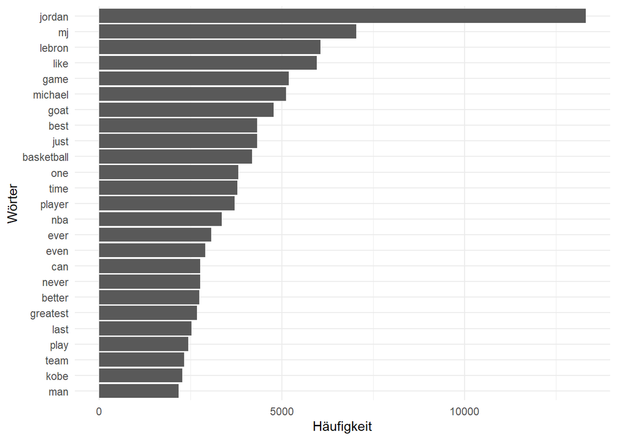

Das Wort, das mit Abstand am häufigsten in den Kommentaren auftaucht, ist `jordan`, also der Nachname der Hauptperson der YouTube-Videos. Dahinter folgt auf Platz zwei sein Spitzname `mj`; sein Vorname `michael` landet immerhin auf Platz sechs. Auffällig ist, dass `lebron` es auf den dritten Platz der häufigsten Wörter schafft. Das ist bemerkenswert, schließlich wurden ausschließlich Kommentare zu Michael-Jordan-Videos heruntergeladen. Offenbar findet in den Kommentarspalten eine `goat`-Diskussion statt. Passend dazu tauchen auch die Einzelbestandteile `greatest` und `time` auf (`of` und `all` wurden zuvor als stopwords herausgefiltert). Auch das Wort `ever` deutet auf die `goat`-Diskussion hin, beispielsweise als Teil der häufig genutzten Wendung “`greatest` to `ever` `play` the `game`”. Auch `kobe` Bryant wird häufig erwähnt – allerdings deutlich seltener als `lebron` James.

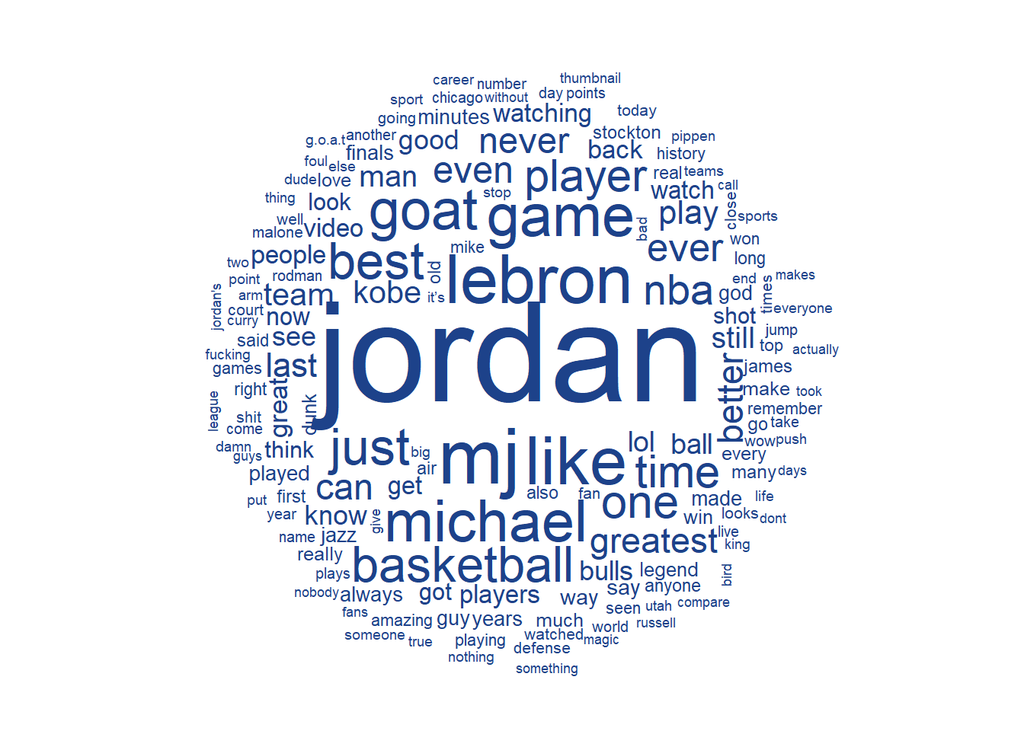

```r
# Wordcloud
textplot_wordcloud(mj_dtm,
                   min_count = 500,
                   color = "#1D428A",
                   max_size = 8)
```

Die Wordcloud stellt Wörter entsprechend ihrer Häufigkeit unterschiedlich groß dar. Je öfter ein Wort in den Kommentaren vorkommt, desto größer erscheint es hier. Dargestellt sind Wörter, die mindestens 500-mal in den Kommentaren zu den analysierten Videos auftauchen. Neben zahlreichen basketballspezifischen Begriffen wie etwa `points`, `defense` oder `foul` erscheinen auch Namen verschiedener Spieler. So sind etwa Jordans ehemalige Mitspieler `pippen` und `rodman`, aber auch die Utah-Jazz-Spieler `stockton` und `malone`, deren Nennung auf das Video der NBA Finals 1998 gegen die Jazz zurückzuführen ist, mit 500 oder mehr Kommentaren vertreten. Vermutlich im Zuge der GOAT-Konversation tauchen neben den bereits erwähnten `lebron` und `kobe` noch `curry`, `russell` und `bird` auf.

## 4. Sentiment-Analyse mit AFINN

Für die Sentiment-Analyse kommt das 2477 Wörter enthaltende AFINN-Lexikon zum Einsatz, mit dem den tokenisierten YouTube-Kommentaren ein Wert von -5 (sehr negativ) bis +5 (sehr positiv) zugeordnet wird. Dieser Ansatz, bekannt als “bag-of-words”-Methode, berücksichtigt nicht die Reihenfolge oder den direkten Kontext einzelner Wörter, sondern wirft diese in einen Topf [(Spörlein, o.D.)](https://www.cSpörlein.com/files/textanalyse.html#analysing_social_media_data). Zudem werden damit nur YouTube-Kommentare berücksichtigt, die mindestens ein Wort enthalten, das Teil des AFINN-Lexikons ist. Trotz dieser Einschränkungen ist es mit diesem Ansatz denkbar, messbare Effekte sichtbar zu machen. Weil der Datensatz zu jedem Kommentar auch ein Datum beinhaltet, können die YouTube-Kommentare mit Sentiment-Wert im Zeitverlauf betrachtet werden.

Michael Jordan hat laut ESPN am Tag der Meisterparade von LeBron James und den Cleveland Cavaliers im Juni 2016 zugestimmt, die zuvor unveröffentlichten Videoaufnahmen freizugeben (Shelbourne, 2020). Die Ausstrahlung der Dokumentation begann schließlich am 19. April 2020. In diesem Abschnitt möchte ich nun herausfinden, ob sich das Stimmungsbild in den Kommentaren von Michael-Jordan-Videos durch die Veröffentlichung von “The Last Dance” verändert hat.

### AFINN-Wörterbuch und Aggregation auf Kommentarebene

Dieses Mal kommt für die Tokenisierung das tidytext-Paket zum Einsatz. Dabei wird der Datensatz mit den Kommentaren erneut in einzelne Wörter zerlegt. Das Entfernen von stopwords, Symbolen oder Links entfällt, da nach der Verknüpfung mit den AFINN-Scores ohnehin nur Wörter verbleiben sollen, für die ein Sentiment-Wert existiert. Der Abgleich zwischen `mj_tokens` und `afinn` mit dem `inner_join()`-Befehl sorgt nun dafür, dass ein neuer Datensatz vorliegt, in dem nur noch Wörter aus den YouTube-Kommentaren vorkommen, denen ein Sentiment-Score zugewiesen wurde. Eine Ausgabe der ersten zehn Zeilen des verbundenen Datensatzes zeigt beispielhaft Wörter (`word`) mit ihrem AFINN-Score (`value`), unter anderem zweimal `greatest` mit dem AFINN-Score von 3.

```r
# Tokenisierung
mj_tokens <- mj_data_filtered %>%
  unnest_tokens(word, Comment)

# Wortliste AFINN laden
afinn <- get_sentiments("afinn")

# inner_join: nur Wörter mit sentiments behalten
mj_tokens_afinn <- mj_tokens %>%
  inner_join(afinn, by = "word") %>%
  select(-ReplyCount, -LikeCount, -PublishedAt) %>%
  select(date, word, value, everything())

# erste zehn Zeilen anzeigen
head(mj_tokens_afinn, 10)
```

```
## # A tibble: 10 × 7
##    date       word     value AuthorChannelID          CommentID   VideoID source
##    <date>     <chr>    <dbl> <chr>                    <chr>       <chr>   <chr>
##  1 2021-02-17 thanks       2 UCU8d7rcShA7MGuDyYH1aWGg UgyaSMUYX2… LAr6oA… video…
##  2 2021-02-17 best         3 UCU8d7rcShA7MGuDyYH1aWGg UgyaSMUYX2… LAr6oA… video…
##  3 2021-02-17 wish         1 UCU8d7rcShA7MGuDyYH1aWGg UgyaSMUYX2… LAr6oA… video…
##  4 2021-02-17 good         3 UCU8d7rcShA7MGuDyYH1aWGg UgyaSMUYX2… LAr6oA… video…
##  5 2024-12-31 god          1 UCAdYDuKvSoMOF5rhjU5MkYw UgzEvBZ3Om… LAr6oA… video…
##  6 2024-12-26 lucky        3 UC_wVnBX_v1NE-gzNlwGgtsg UgzDZ8aszj… LAr6oA… video…
##  7 2024-12-23 best         3 UCfdI-03hK55S3jczVEwHnsA UgxibmuryE… LAr6oA… video…
##  8 2024-12-22 greatest     3 UCPYwOayFnZjn6ZKiCNTp2Xg UgyjKseqWb… LAr6oA… video…
##  9 2024-12-22 greatest     3 UCPYwOayFnZjn6ZKiCNTp2Xg UgyjKseqWb… LAr6oA… video…
## 10 2024-12-22 strength     2 UC0GQ9WUH5M6LcIFsYE02vFw UgwV-F_WD_… LAr6oA… video…
```

Eine Visualisierung der Häufigkeiten der AFINN-Scores (bezogen auf die einzelnen Tokens aus den YouTube-Kommentaren) zeigt, dass der Score 3 am häufigsten zugewiesen wurde, dicht gefolgt von 2. Negative Werte wie -1 und -2 kommen ebenfalls relativ häufig vor. Der höchste Wert +5 hingegen wurde nur 52-mal einem Wort zugeordnet.

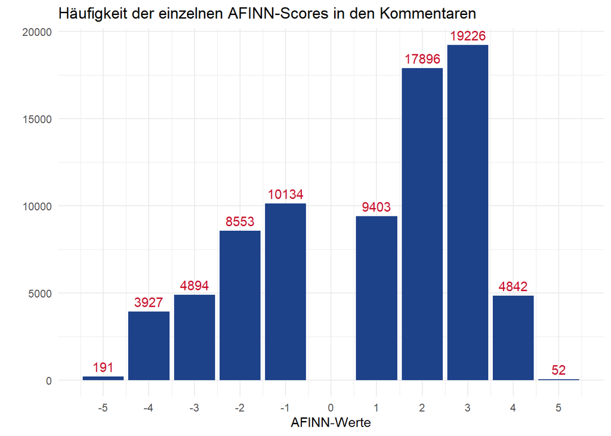

```r
# Plot zur Häufigkeit der AFINN-Scores
ggplot(mj_tokens_afinn, aes(x = value)) +
  geom_bar(fill = "#1D428A") +
  geom_text(stat='count', aes(label=..count..), vjust=-0.5, color="#C8102E") +
  scale_x_continuous(breaks = -5:5) +
  labs(
    title = "Häufigkeit der einzelnen AFINN-Scores in den Kommentaren",
    x = "AFINN-Werte",
    y = ""
  ) +
  theme_minimal()
```

Das AFINN-Wörterbuch besitzt nur fünf Wörter mit dem höchsten Wert: `breathtaking`, `hurrah`, `outstanding`, `superb` und `thrilled`.

```
## # A tibble: 5 × 2
##   word         value
##   <chr>        <dbl>
## 1 breathtaking     5
## 2 hurrah           5
## 3 outstanding      5
## 4 superb           5
## 5 thrilled         5
```

Bis auf `hurrah` kommen diese Wörter alle mindestens einmal in den heruntergeladenen YouTube-Kommentaren vor, wie sich mit diesem Code feststellen lässt:

```r
# Wörter aus AFINN mit höchstem Wert 5 in den vorliegenden Tokens
mj_tokens_afinn %>%
  filter(value == 5) %>%
  distinct(word)
```

```
## # A tibble: 4 × 1
##   word
##   <chr>
## 1 outstanding
## 2 thrilled
## 3 superb
## 4 breathtaking
```

Nachdem die YouTube-Kommentare zunächst in Tokens zerlegt wurden, um den einzelnen Wörtern einen AFINN-Score zuzuordnen, werden die Tokens nun wieder auf Kommentarebene aggregiert. Die aggregierten Kommentare werden mit dem ursprünglichen Datensatz verknüpft, der die Datumsvariable enthält. Dabei erstelle ich eine Variable `afinn_mean`, die für jeden Kommentar den Durchschnitts-Sentiment-Wert widerspiegelt. An dieser Stelle wäre es ebenfalls denkbar gewesen, einen Gesamtscore für jeden Kommentar zu berechnen. Der Mittelwert hat jedoch den Vorteil, dass längere Kommentar nicht unverhältnismäßig stark Einfluss nehmen.

```r
# Aggregation auf Kommentar-Ebene
mj_afinn_comments <- mj_tokens_afinn %>%
  group_by(CommentID) %>%
  summarise(
    afinn_total = sum(value),
    word_count = n(),
    afinn_mean = mean(value)
  )

# Datensatz mit neuen Variablen mit Ursprungsdaten mergen
mj_afinn_comments <- mj_data_filtered %>%
  inner_join(mj_afinn_comments, by = "CommentID") %>%
  select(Comment, date, afinn_total, afinn_mean, word_count, everything())
```

Nach der Aggregation auf Kommentarebene ist es nun möglich, sich Kommentare auszugeben, die eines der oben aufgezeigten Wörtern mit einem AFINN-Score von 5 enthalten. Die ersten fünf Kommentare im Datensatz, auf die das zutrifft, werden beispielhaft hier angezeigt:

```r
# Kommentaranzahl mit mindestens einem AFINN-Score von 5
mj_tokens_afinn %>%
  filter(value == 5) %>%
  distinct(CommentID) %>%
  nrow()
```

```
## [1] 48
```

```r
# Comment-IDs der Tokens mit Score 5 ermitteln
comments_score5 <- mj_tokens_afinn %>%
  filter(value == 5) %>%
  pull(CommentID)

# Kommentare extrahieren
full_comments_score5 <- mj_data_filtered %>%
  filter(CommentID %in% comments_score5) %>%
  distinct(Comment) %>%
  head(5) %>%
  pull(Comment)

# Kommentare komplett anzeigen
cat(full_comments_score5, sep = "\n\n")
```

```
## Outstanding.
##
## You can’t compare different kind of sports and every decade has their "Greatest" like Ali, Pele, Maradona, Messi, Ronaldo, Phelps, Federer, Thorpe, Woods, Gretzky, Ruth, Brady, Bolt, Tyson, Manning, Orr, Favre, Montana, Armstrong… just to name a few BUT Jordan had the total package, nobody has em…
## THE GOAT 🐐 #23 Michael Jeffrey Jordan
##
## Why Michael Jordan is the G.O.A.T of Basketball?
## 1)   Delivered 3 peats dynasty of 6 consecutive NBA championships (1991,1992,1993, 1996, 1997,1998)
## 2)   Most number of MVP awards (11)
## 3)   Certified Dunk Champion
## 4)   Great jump shooter
## 5)   Fast breaker
## 6)   A shooting guard and Point guard
## 7)   Superb lay ups
##
## Michael Jordan is an example for many athletes not only basketball, but also other sports! Because no one in the world has ever managed to achieve such success in the whole history! There were and are many athletes who were outstanding! But no one could associate your name with the species itself…
##
## Michaels movings were a beauty of choreography 🤩
##
## So fast, so elegant, absolutely outstanding and never seen again …
##
## Personally I think he is the greatest, most talented and most spectacular athlete at all the planet ever had so far
```

### Sentiment-Analyse

#### langfristiger Vergleich: 2015 bis 2024

Für den langfristigen Vergleich wird der Datensatz betrachtet, der vom 4. September 2015 bis zum 31. Dezember 2024 reicht.

```r
# pre/post-Variablen erstellen
mj_afinn_comments <- mj_afinn_comments %>%
  mutate(
    pre_post = factor(case_when(
      date <= as.Date("2020-04-18") ~ "vor Doku",
      date >= as.Date("2020-05-18") ~ "nach Doku"
    ), levels = c("vor Doku", "nach Doku")),
    period_1y = factor(case_when(
      date >= as.Date("2019-04-19") & date <= as.Date("2020-04-18") ~ "1 Jahr davor",
      date >= as.Date("2020-04-19") & date <= as.Date("2021-04-18") ~ "1 Jahr danach"
    ), levels = c("1 Jahr davor", "1 Jahr danach")),
    period_kurz = factor(case_when(
      date >= as.Date("2020-01-19") & date <= as.Date("2020-04-18") ~ "3 Monate davor",
      date >= as.Date("2020-04-19") & date <= as.Date("2020-07-18") ~ "3 Monate danach"
    ), levels = c("3 Monate davor", "3 Monate danach"))
  )

# Häufigkeitsauszählung
table(mj_afinn_comments$pre_post)
```

```
##
##  vor Doku nach Doku
##     17180     20009
```

```r
# Mittelwerte
tapply(mj_afinn_comments$afinn_mean, mj_afinn_comments$pre_post, mean, na.rm=TRUE)
```

```
##  vor Doku nach Doku
## 0.9592876 0.8647378
```

Der mittlere AFINN-Score beträgt für die Phase vor der Doku 0,96 und für die Phase nach der Doku 0,86. Dies widerspricht der Erwartung, dass die Veröffentlichung der Doku das Sentiment gegenüber Jordan positiv beeinflusst hat.

#### mittelfristiger Vergleich: ± 1 Jahr

Für den mittelfristigen Vergleich wird der Untersuchungszeitraum auf ein Jahr vor und ein Jahr nach Veröffentlichung der Doku verkürzt. Das Ergebnis ist ähnlich. Im Jahr vor der Doku lag der durchschnittliche Sentiment-Wert bei 1,03; im Jahr danach bei 0,91.

```r
# Häufigkeitsauszählung
table(mj_afinn_comments$period_1y)
```

```
##
##  1 Jahr davor 1 Jahr danach
##          4737          5994
```

```r
# Mittelwerte
tapply(mj_afinn_comments$afinn_mean, mj_afinn_comments$period_1y, mean, na.rm=TRUE)
```

```
##  1 Jahr davor 1 Jahr danach
##     1.0275675     0.9141502
```

#### kurzfristiger Vergleich: ± 3 Monate

Beim kürzesten Untersuchungszeitraum von drei Monaten vor und nach der Doku unterscheiden sich die Mittelwerte mit 1,05 und 1,06 kaum.

```r
# Häufigkeitsauszählung
table(mj_afinn_comments$period_kurz)
```

```
##
##  3 Monate davor 3 Monate danach
##            1602            1221
```

```r
# Mittelwerte
tapply(mj_afinn_comments$afinn_mean, mj_afinn_comments$period_kurz, mean, na.rm=TRUE)
```

```
##  3 Monate davor 3 Monate danach
##        1.052076        1.058222
```

#### 3-Monats-Vergleich: 18. Mai bis 18. August

Als letztes werden noch die Sentiment-Werte in den drei Monaten nach Ausstrahlung der Doku im Jahr 2020 mit demselben Zeitraum in den anderen Jahren verglichen. Dabei fällt ins Auge, dass der Wert im Jahr 2020 am höchsten ist. Es ist das einzige Jahr, in dem der Durchschnitts-Wert über 1 liegt; mit 1,15 sogar relativ deutlich darüber.

```r
# Variable für Jahr
mj_afinn_comments <- mj_afinn_comments %>%
  mutate(year = year(date))

# Filter für Zeitraum 18. Mai bis 18. August
mj_kurz_period <- mj_afinn_comments %>%
  mutate(
    period_start = as.Date(paste0(year, "-05-18")),
    period_end   = as.Date(paste0(year, "-08-18"))
  ) %>%
  filter(date >= period_start, date <= period_end)

# durchschnittlichenr Sentiment-Wert pro Jahr und Kommentaranzahl in diesem Zeitraum
jahres_sentiment <- mj_kurz_period %>%
  group_by(year) %>%
  summarise(
    mean_sentiment = mean(afinn_mean, na.rm = TRUE),
    n_comments = n()
  )

print(jahres_sentiment)
```

```
## # A tibble: 9 × 3
##    year mean_sentiment n_comments
##   <dbl>          <dbl>      <int>
## 1  2016          0.808       1064
## 2  2017          0.882        793
## 3  2018          0.882       1402
## 4  2019          0.889       1228
## 5  2020          1.15         921
## 6  2021          0.651       3235
## 7  2022          0.889       1377
## 8  2023          0.995        507
## 9  2024          0.824        310
```

Als Erklärung dafür kommen mehrere Gründe in Betracht. Möglicherweise hatte die Veröffentlichung der Doku keinen oder einen nur sehr geringen Effekt, der zusätzlich durch algorithmische Schwankungen überlagert sein könnte. Oder die Sentiment-Analyse mit AFINN ist nicht oder nur bedingt geeignet, um die Forschungsfrage zu beantworten. Zudem eignet sich die Einteilung in (große) Zeitblöcke zwar für einen explorativen Vorher-Nachher-Vergleich, allerdings werden damit verschiedene Faktoren über einen (langen) Zeitraum “zusammengefasst”, ohne für deren individuellen Einfluss zu kontrollieren. Ebenfalls ist es denkbar, dass andere sportliche Ereignisse rund um die NBA einen viel größeren Einfluss ausüben als die Ausstrahlung einer Netflix-Doku. Wir haben in Abschnitt 3 gesehen, dass LeBron James in den YouTube-Kommentaren zu Michael-Jordan-Videos präsent ist – `lebron` ist nach `jordan` und `mj` das drittmeist genannte Wort. Daher soll im nächsten Abschnitt der mögliche Einfluss von LeBron James genauer untersucht werden.

## 5. LeBron James

### Meilensteine

Um mögliche Einflüsse von Ereignissen rund um LeBron James auf das Sentiment in Michael-Jordan-Videos besser zu verstehen, betrachten wir zunächst die monatliche Entwicklung des durchschnittlichen Sentiments von 2015 bis 2024. Neben dem Start der Doku werden vier Daten bedeutender sportlicher Ereignisse in James’ Karriere, die in diesen Zeitraum fallen, mit gestrichelten Linien visualisiert:

- Am **19. Juni 2016** beschert James den Cleveland Cavaliers den ersten NBA-Titel ihrer Geschichte in Game 7 in den NBA-Finals gegen Golden State und wird zum dritten Mal Finals-MVP.
- Am **27. Mai 2018** gewinnen die Cavaliers Spiel 7 in den Conference-Finals gegen die Boston Celtics. James spielt historisch starke Playoffs und führt Cleveland quasi im Alleingang in die Finals, wo sie den Golden State Warriors unterliegen.
- Am **11. Oktober 2020** gewinnt James seinen vierten NBA-Titel insgesamt, erstmals mit den Los Angeles Lakers. Er wird erneut als Finals-MVP ausgezeichnet.
- Am **07. Februar 2023** wird “LeBron” mit 38.387 Punkten All-Time-Scoring-Leader der NBA-Geschichte. Er überholt Kareem Abdul-Jabbar, dessen Rekord fast 39 Jahre Bestand hatte.

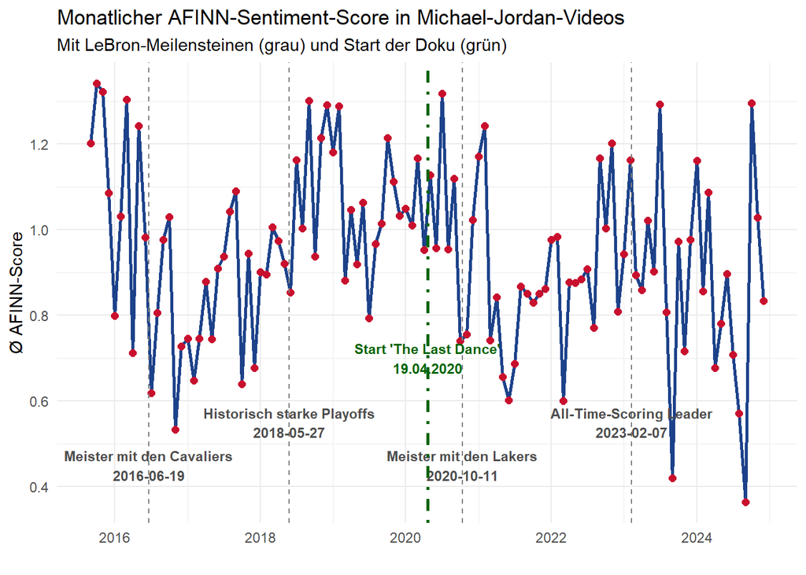

```r
# Aggregation: Durchschnittlicher AFINN-Score pro Monat
sentiment_month <- mj_afinn_comments %>%
  mutate(month = floor_date(date, "month")) %>%
  group_by(month) %>%
  summarise(mean_sentiment = mean(afinn_mean, na.rm = TRUE),
            n_comments = n())

# Meilensteine
meilensteine_df <- data.frame(
  date = as.Date(c("2016-06-19", "2018-05-27", "2020-10-11", "2023-02-07")),
  label = c("Meister mit den Cavaliers",
            "Historisch starke Playoffs",
            "Meister mit den Lakers",
            "All-Time-Scoring Leader")
)

# Data frame und Anpassung für Darstellung im Plot
meilensteine_df <- meilensteine_df %>%
  mutate(
    full_label = paste0(label, "\n", date),
    y_pos = ifelse(row_number() %in% c(2, 4), 0.55, 0.45)
  )

last_dance_df <- data.frame(
  date = as.Date("2020-04-19"),
  label = "Start 'The Last Dance'\n19.04.2020"
)


# Plot erstellen
ggplot(sentiment_month, aes(x = month, y = mean_sentiment)) +
  geom_line(color = "#1D428A", size = 1) +
  geom_point(color = "#C8102E", size = 2) +
  labs(
    title = "Monatlicher AFINN-Sentiment-Score in Michael-Jordan-Videos",
    subtitle = "Mit LeBron-Meilensteinen (grau) und Start der Doku (grün)",
    x = "",
    y = "Ø AFINN-Score"
  ) +
  theme_minimal() +
  geom_vline(
    data = meilensteine_df,
    aes(xintercept = as.numeric(date)),
    linetype = "dashed",
    color = "gray50"
  ) +
  geom_text(
    data = meilensteine_df,
    aes(x = date, y = y_pos, label = full_label),
    color = "gray30",
    fontface = "bold",
    size = 3
  ) +
  geom_vline(
    data = last_dance_df,
    aes(xintercept = as.numeric(date)),
    color = "darkgreen",
    linetype = "dotdash",
    size = 1
  ) +
  geom_text(
    data = last_dance_df,
    aes(x = date, y = 0.7, label = label),
    color = "darkgreen",
    fontface = "bold",
    size = 3
  )
```

Der durchschnittliche Sentiment-Score steigt mit dem Erscheinen der Doku kurzfristig an. Bei starken Leistungen LeBrons (2016, 2018 und 2020) geht das Sentiment in Michael-Jordan-Videos nach unten. Teilweise beginnt diese Entwicklung des sinkenden Zuspruchs bereits im Vormonat des jeweils geplotteten Datums, was auf die rund zweimonatige Dauer der NBA-Playoffs zurückzuführen sein könnte. Im Monat des Scoring-Rekords im Februar 2023 bleibt das Sentiment zunächst hoch und fällt erst danach ab. Rein deskriptiv lassen sich also mehrere kurzfristige Änderungen im Sentiment beobachten. Dabei lässt sich vermuten, dass reale Ereignisse in der NBA – in diesem Fall rund um LeBron James – die Stimmung in Michael-Jordan-Videos beeinflussen.

### Häufigkeitsanalyse

Nachdem wir gesehen haben, dass in den YouTube-Kommentaren häufig über Lebron James gesprochen wurde und dass seine Leistungen in der NBA vermutlich Auswirkungen auf die untersuchten Sentiments in YouTube-Kommentaren zu Michael-Jordan-Videos haben, soll als letzter Analyseschritt die Häufigkeit der Erwähnung von Lebron James in den Kommentaren untersucht werden. Dabei wird die Untersuchung wieder in verschiedene Zeiträume analog zu Abschnitt 4 eingeteilt, um zu prüfen, ob James in den YouTube-Kommentaren zu Michael-Jordan-Videos vor oder nach der Veröffentlichung von “The Last Dance” häufiger erwähnt wurde.

```r
# Tokens mit "lebron" oder "james"
lebron_tokens <- mj_tokens %>%
  filter(word %in% c("lebron", "james"))

# Häufigkeit Vorkommen in Kommentar
lebron_counts <- lebron_tokens %>%
  group_by(CommentID) %>%
  summarise(lebron_count = n())

# Mit Ursprungsdatensatz mergen
mj_lebron <- mj_data_filtered %>%
  left_join(lebron_counts, by = "CommentID") %>%
  mutate(lebron_count = ifelse(is.na(lebron_count), 0, lebron_count))

# pre/post-Variablen erstellen
mj_lebron <- mj_lebron %>%
  mutate(
    pre_post = factor(case_when(
      date <= as.Date("2020-04-18") ~ "pre",
      date >= as.Date("2020-05-18") ~ "post"
    ), levels = c("pre", "post")),
    period_mittel = factor(case_when(
      date >= as.Date("2019-04-19") & date <= as.Date("2020-04-18") ~ "1 Jahr davor",
      date >= as.Date("2020-05-18") & date <= as.Date("2021-05-17") ~ "1 Jahr danach"
    ), levels = c("1 Jahr davor", "1 Jahr danach")),
    period_kurz = factor(case_when(
      date >= as.Date("2020-01-19") & date <= as.Date("2020-04-18") ~ "3 Monate davor",
      date >= as.Date("2020-05-18") & date <= as.Date("2020-08-17") ~ "3 Monate danach"
    ), levels = c("3 Monate davor", "3 Monate danach"))
  )

# kategoriale Variable erstellen
mj_lebron <- mj_lebron %>%
  mutate(
    lebron_kat = ifelse(lebron_count > 0, "ja", "nein")
  )

## Langfristiger Vergleich
mj_lebron_lang <- mj_lebron  %>%
   filter(!is.na(pre_post))

# Gruppierung nach pre_post für absolute und relative Häufigkeiten
frequency_lebron_lang <- mj_lebron_lang %>%
  group_by(pre_post) %>%
  summarise(
    total_lebron = sum(lebron_count),
    total_comments = n(),
    relative_freq = total_lebron / total_comments
  )

# Kreuztabelle und Zeilenprozente
kreuztabelle_lang <- table(mj_lebron_lang$pre_post, mj_lebron_lang$lebron_kat)
zeilenprozente_lang <- prop.table(kreuztabelle_lang, 1) * 100

## Mittelfristiger Vergleich
mj_lebron_mittel <- mj_lebron %>%
  filter(!is.na(period_mittel))
# Gruppierung nach period_mittel für absolute und relative Häufigkeiten
frequency_lebron_mittel <- mj_lebron_mittel %>%
  group_by(period_mittel) %>%
  summarise(
    total_lebron = sum(lebron_count),
    total_comments = n(),
    relative_freq = total_lebron / total_comments
  )

# Kreuztabelle und Zeilenprozente
kreuztabelle_mittel <- table(mj_lebron_mittel$period_mittel, mj_lebron_mittel$lebron_kat)
zeilenprozente_mittel <- prop.table(kreuztabelle_mittel, 1) * 100

## Kurzfristiger Vergleich
mj_lebron_kurz <- mj_lebron %>%
  filter(!is.na(period_kurz))
# Gruppierung nach period_kurz für absolute und relative Häufigkeiten
frequency_lebron_kurz <- mj_lebron_kurz %>%
  group_by(period_kurz) %>%
  summarise(
    total_lebron = sum(lebron_count),
    total_comments = n(),
    relative_freq = total_lebron / total_comments
  )

# Kreuztabelle und Zeilenprozente
kreuztabelle_kurz <- table(mj_lebron_kurz$period_kurz, mj_lebron_kurz$lebron_kat)
zeilenprozente_kurz <- prop.table(kreuztabelle_kurz, 1) * 100
```

Dazu werden im bereits vorhandenen Datensatz mit den Tokens (siehe Abschnitt 4) alle Tokens identifiziert, die “lebron” oder “james” enthalten. Die Groß- bzw. Kleinschreibung kann dabei vernachlässigt werden, da nach der Tokenisierung ohnehin alle Wörter klein geschrieben vorliegen. Nach der Aggregation auf Kommentarebene wird eine Häufigkeitsvariable `lebron_count` erstellt, die angibt, wie häufig “lebron” oder “james” in einem Kommentar vorkommt. Anschließend wird der Merge mit dem Ursprungsdatensatz durchgeführt und für alle Kommentare, in denen LeBron James nicht erwähnt wird, eine 0 vergeben.

Es wird für alle zu untersuchenden Zeiträume eine pre-post-Variable erstellt, die den Ausstrahlungszeitraum der Doku ausspart. Damit können anschließend die absoluten und relativen Häufigkeiten (d.h. der Anteil an Kommentaren, die “lebron” oder “james” enthalten) berechnet werden. Dazu wird eine kategoriale Variable erstellt, die dichotom unterscheidet, ob ein Kommentar mindestens einmal “lebron” oder “james” enthält oder eben nicht. Mithilfe von Zeilenprozenten können wir uns – neben den relativen Anteilen – auch anschauen, wie hoch der Anteil an Kommentaren ist, die mindestens einmal “lebron” oder “james” enthalten.

#### langfristiger Vergleich: 2015 bis 2024

```
## # A tibble: 2 × 4
##   pre_post total_lebron total_comments relative_freq
##   <fct>           <dbl>          <int>         <dbl>
## 1 pre              4024          30767        0.131
## 2 post             2892          37053        0.0781
```

```
##
##               ja      nein
##   pre   9.318426 90.681574
##   post  5.756619 94.243381
```

Der Anteil von Kommentaren mit LeBron-Erwähnungen liegt vor der Doku bei 13,1 Prozent. Im Zeitraum nach der Doku liegt der Anteil bei 7,8 Prozent. Der Anteil an Kommentaren, die mindestens einmal LeBron James erwähnen, liegt vor der Doku bei 9,3 Prozent und nach der Doku bei 5,7 Prozent.

#### mittelfristiger Vergleich: ± 1 Jahr

```
## # A tibble: 2 × 4
##   period_mittel total_lebron total_comments relative_freq
##   <fct>                <dbl>          <int>         <dbl>
## 1 1 Jahr davor           948           8933        0.106
## 2 1 Jahr danach         1049          11868        0.0884
```

```
##
##                        ja      nein
##   1 Jahr davor   7.533863 92.466137
##   1 Jahr danach  6.555443 93.444557
```

Im mittelfristigen Vergleich zeigt sich ein ähnliches, jedoch weniger ausgeprägtes Bild. In dem Jahr vor Veröffentlichung der Doku beträgt der Anteil 10,6 Prozent im Vergleich zu 8,9 Prozent im Jahr danach. Bei den Zeilenprozenten ist der Unterschied beim mittelfristigen Vergleich ebenfalls geringer. Dies ist bemerkenswert, weil LeBron James im Oktober 2020 mit den Los Angeles Lakers den Titel gewann.

#### kurzfristiger Vergleich: ± 3 Monate

```
## # A tibble: 2 × 4
##   period_kurz     total_lebron total_comments relative_freq
##   <fct>                  <dbl>          <int>         <dbl>
## 1 3 Monate davor           240           3077        0.0780
## 2 3 Monate danach          130           1690        0.0769
```

```
##
##                          ja      nein
##   3 Monate davor   5.849854 94.150146
##   3 Monate danach  5.562130 94.437870
```

Auch im kurzfristigen Zeitraum von drei Monaten zeigt sich, dass LeBron James nach der Doku seltener erwähnt wird als davor. Dieser Unterschied ist aber sowohl beim relativen Anteil als auch bei der dichotomen Variable sehr gering.

#### 3-Monats-Vergleich: 18. Mai bis 18. August

```r
# Jahresvariable
mj_lebron <- mj_lebron %>%
  mutate(year = year(date))

# Filter: 18.05. bis 18.08. für jedes Jahr von 2016 bis 2024:
mj_lebron_3m <- mj_lebron %>%
  mutate(
    period_start = as.Date(paste0(year, "-05-18")),
    period_end   = as.Date(paste0(year, "-08-18"))
  ) %>%
  filter(date >= period_start & date <= period_end)

# Aggregation: LeBron-Nennungen pro Jahr, Kommentaranzahl und durchschnittlicher LeBron-Count pro Kommentar
frequency_jahre <- mj_lebron_3m %>%
  group_by(year) %>%
  summarise(
    total_lebron = sum(lebron_count),
    total_comments = n(),
    relative_freq = total_lebron / total_comments)

# Kreuztabelle
kreuztabelle_3m <- table(mj_lebron_3m$year, mj_lebron_3m$lebron_kat)

# Zeilenprozente
zeilenprozente_jahre <- prop.table(kreuztabelle_3m, 1) * 100
```

Vom 18. Mai bis zum 18. August 2020 ist der relative Anteil an Erwähnungen von LeBron James in den Kommentaren auffallend gering. Mit 7,7 Prozent ist dies – abgesehen vom Jahr 2024 mit einer sehr geringen Fallzahl – der niedrigste Wert aller Jahre. Dies ist womöglich darauf zurückzuführen, dass im Jahr 2020 die Playoffs wegen der Pandemie nicht im Mai und Juni ausgetragen wurden. Aus diesem Grund sind Vergleiche des Jahres 2020 mit den anderen nur sehr bedingt zielführend. Am höchsten ist der relative Anteil im Jahr 2018 mit 20,8 Prozent; das Jahr, in dem James eine der besten individuellen Playoff-Leistungen der NBA-Geschichte hingelegt hat. Die Zeilenprozente zur kategorialen Variable zeigen, dass der Anteil an Kommentaren mit mindestens einer Erwähnung mit 15,1 Prozent ebenfalls im Jahr 2018 am höchsten ist.

```
## # A tibble: 9 × 4
##    year total_lebron total_comments relative_freq
##   <dbl>        <dbl>          <int>         <dbl>
## 1  2016          205           1722        0.119
## 2  2017          213           1421        0.150
## 3  2018          491           2358        0.208
## 4  2019          322           2270        0.142
## 5  2020          131           1702        0.0770
## 6  2021          425           5219        0.0814
## 7  2022          220           2542        0.0865
## 8  2023          107            961        0.111
## 9  2024           43            575        0.0748
```

```
##
##               ja      nein
##   2016  7.200929 92.799071
##   2017 10.696692 89.303308
##   2018 15.055131 84.944869
##   2019 10.748899 89.251101
##   2020  5.581669 94.418331
##   2021  5.671585 94.328415
##   2022  5.782848 94.217152
##   2023  8.532778 91.467222
##   2024  5.391304 94.608696
```

Die Analyse hat ergeben, dass LeBron James bei Betrachtung eines lang- und mittelfristigen Zeitraums vor der Veröffentlichung der Doku am 19. April 2020 deutlich häufiger in den untersuchten YouTube-Kommentaren genannt wird als nach Veröffentlichung der Doku. Für den kurzfristigen Zeitraum von drei Monaten vor und drei Monaten nach der Doku können nur minimale Unterschiede ausgemacht werden. Warum James in den Zeiträumen vor der Doku häufiger genannt wird, kann verschiedene Gründe haben. Möglicherweise hat die Ausstrahlung von “The Last Dance” dafür gesorgt, dass in den Kommentarspalten zu Michael-Jordan-Videos der Fokus wieder mehr auf “MJ” gelegt wurde.

Wahrscheinlicher ist wohl eine andere Erklärung: James stieg nach seinem Titelgewinn mit den Cavaliers im Jahr 2016 womöglich so richtig in die GOAT-Konversation auf und hat mit seinen fulminanten Playoffs im Jahr 2018 diese Diskussion weiter angeheizt. Das Jahr 2018 unterscheidet sich jedenfalls hinsichtlich der Nennung von James deutlich von allen anderen. Der Anteil an Kommentaren, in denen James erwähnt wird, ist hier am höchsten. Zwei Jahre nach dem ersten Titel mit Cleveland lieferte LeBron eine historisch starke Playoff-Leistung, weshalb die GOAT-Diskussion hier womöglich auf dem Höhepunkt war. Jedoch zeichnen die Daten kein komplett rundes Bild, denn die Erwähnung seines Namens hat trotz des Titelgewinns mit den Lakers 2020 nicht zugenommen. Eine mögliche Erklärung: Dem Titel 2020 wird unter NBA-Fans häufig die Legitimität abgesprochen, weil dieser während der COVID-19-Pandemie und in der “Bubble” – gespielt wurde im Disney Land in Orlando – gewonnen wurde (Marvi, 2020).

## 6. Fazit und Ausblick

In dieser quantitativen Textanlyse bin ich der Frage nachgegangen, inwiefern die Veröffentlichung der Netflix-Doku “The Last Dance” die Wahrnehmung von Michael Jordan auf YouTube beeinflusst hat. Dazu habe ich Kommentare zu vier Highlight-Videos von Jordan heruntergeladen und ausgewertet. Die deskriptive Analyse hat gezeigt, dass die generelle Kommentaraktivität ansteigt, wenn die NBA-Saison in die heiße Phase geht. Womöglich gibt es hier eine Wechselwirkung mit algorithmischen Effekten: Höheres Zuschauerinteresse während der Playoffs führt zu mehr Aufrufen, wodurch die Videos verstärkt vom YouTube-Algorithmus empfohlen werden. Die Betrachtung von Worthäufigkeiten hat ergeben, dass – wenig überraschend – die Wörter `jordan` und `mj` am häufigsten genannt werden. Mit Platz 3 liegt `lebron` bei den meistgenannten Wörtern bemerkenswert weit oben. Auch andere Wörter in den Top25 (z. B. `goat`) lassen darauf schließen, dass in den YouTube-Kommentarspalten unter Michael-Jordan-Videos eine Diskussion darüber stattfindet, wer der beste Basketballer aller Zeiten ist. Dabei liegt James meilenweit vor anderen NBA-Größen wie Kobe Bryant, Larry Bird, Bill Russell und Steph Curry. Diese Textanalyse kann jedoch keine generelle Aussage über die GOAT-Debatte treffen. Zukünftige Analysen könnten dazu Daten, die sich nicht ausschließlich mit Videos von Michael Jordan beschäftigen, verwenden und andere Methoden anwenden. Mit dem quanteda-Paket könnte beispielsweise das Wort “GOAT” mit dem textstat_simil-Befehl auf Ähnlichkeit mit Jordan oder James untersucht werden [(Spörlein, o. D.)](https://www.cSpörlein.com/files/textanalyse.html#analysing_social_media_data).

Des Weiteren habe ich mithilfe des AFINN-Lexikons die untersuchten YouTube-Kommentare einer Sentiment-Analyse unterzogen. Der Erwartung, dass die Veröffentlichung der Doku das Sentiment in den Kommentaren (positiv) beeinflusst hat, wurde dabei nur zum Teil entsprochen. Zwar lässt sich ein kurzfristiger Anstieg des Sentiments bei Veröffentlichung der Doku erkennen. In Analysen zu längerfristigen Auswirkungen, die den Zeitraum der Ausstrahlung aussparen, ergibt sich jedoch kein dauerhafter Anstieg des Sentiments. Dies könnte unter anderem methodische Gründe haben, denn die Analyse mit AFINN unterliegt einigen Einschränkungen: Mit der “bag-of-words”-Methode werden alle Wörter in einem Topf geworfen, wodurch der Kontext außer Acht gelassen wird. Ironie wird nicht erkannt und auch Negationen fließen nicht in die Bewertung ein. Hier ist es also fraglich, ob wirklich das gemessen wird, was gemessen werden soll. Zukünftige Sentiment-Analysen könnten andere Lexika verwenden, wie beispielsweise [VADER (Valence Aware Dictionary and sEntiment Reasoner)](https://cran.r-project.org/web/packages/vader/vader.pdf). Dieses Verfahren versucht diese Schwächen auszugleichen, indem es zusätzlich zur lexikalischen Bewertung auch sprachliche Regeln berücksichtigt – etwa Satzzeichen, Großschreibung, Intensivierungen oder Negationen – und daraus einen gewichteten Gesamtwert (“compound score”) zwischen –1 (sehr negativ) und +1 (sehr positiv) berechnet. Ebenfalls ist die Einteilung der Daten in zeitliche Blöcke womöglich nur bedingt geeignet, um langfristige Effekte abzubilden. Zeitliche Dynamiken (etwa Playoff-Einflüsse und algorithmische Effekte) werden damit vernachlässigt und die Daten nicht als echte Zeitreihe behandelt. Um kausale Rückschlüsse zu ermöglichen, wären Zeitreihen- oder Panelmodelle erforderlich, die dynamische Entwicklungen des Sentiments im Zeitverlauf erfassen können. Dabei könnten saisonale Schwankungen, algorithmische Effekte, Mehrfachposts derselben Nutzer sowie parallele Ereignisse, etwa die jährlichen NBA-Finals, explizit berücksichtigt und kontrolliert werden.

Darüber hinaus ist denkbar, dass wir es mit bei Netflix- und YouTube-Nutzern mit verschiedenen Zielgruppen zu tun haben, deren Schnittmenge nicht so groß ist wie angenommen. Das könnte bedingen, dass die Veröffentlichung der Doku keinen oder einen nur sehr kleinen Effekt auf die Sentiments in den YouTube-Kommentaren haben. Die Daten sprechen dafür, dass vielmehr reale sportliche Ereignisse einen Einfluss auf die Sentiments nehmen. Spannende Erkenntnisse hat die Analyse zu LeBron James geliefert. Die These, dass sportliche Ereignisse einen deutlichen Einfluss auf die Sentiments haben, bekommt weiteres Futter, wenn man die Sentiments im Zeitverlauf betrachtet und dabei Meilensteine aus James’ Karriere unter die Lupe nimmt. Rein deskriptiv zeigen die Daten, dass starke Leistungen von James in der NBA mit negativen Sentiments gegenüber Michael Jordan einhergehen. In Bezug auf die Forschungsfrage habe ich mir ebenfalls angeschaut, ob James vor oder nach Veröffentlichung der Doku häufiger in den Kommentaren erwähnt wird. Dabei hat sich beim lang- und mittelfristigen Vergleich gezeigt, dass James vor der Doku deutlich häufiger erwähnt wird als danach. Entweder wurde der Fokus nach Ausstrahlung der Doku tatsächlich vermehrt auf Jordan gelegt oder – und das halte ich für plausibler – die GOAT-Konversation wurde ab dem Jahr 2016 aufgrund James’ Leistungen in der NBA richtig hitzig und hat im Jahr 2018 ihren Peak erreicht. Die Daten zeigen, dass der Anteil der Erwähnungen von LeBron James in den Kommentaren im Jahr 2018 mit Abstand am höchsten war. Herauszufinden, ob die GOAT-Debatte im Jahr 2018 wirklich Ihren Höhepunkt hatte, könnte die Aufgabe einer anderen quantitativen Textanalyse sein.

## Quellen

Benoit et al. (2019). [quanteda: Quantitative Analysis of Textual Data](https://quanteda.io).

ESPN (o.D.). [Top N. American Athletes of the Century](https://www.espn.com/sportscentury/athletes.html).

FortOnSports (2015). [LeBron James: The GOAT? The Definition of Greatness, Pt. 1](https://fortonsports.wordpress.com/2015/09/04/lebron-james-the-goat-the-definition-of-greatness-pt-1/?utm_source=chatgpt.com).

Graham & Ackland (2018). [vosonSML: Tools for Collecting Social Media Data and Generating Networks for Analysis](https://www.rdocumentation.org/packages/vosonSML/versions/0.23.4).

Know Your Meme (2021). [Michael Jordan’s “And I Took That Personally”](https://knowyourmeme.com/memes/michael-jordans-and-i-took-that-personally).

Marvi, R. (2020). NBC Sports Boston disses Lakers’ 2020 NBA title: “Disney World title”.

Roehrick, K. (2020). [vader: Package ‘vader’](https://cran.r-project.org/web/packages/vader/vader.pdf).

Shelbourne, R. (2020). [An all-access Michael Jordan documentary? How ‘The Last Dance’ was made possible](https://www.espn.com/nba/story/_/id/29044827/an-all-access-michael-jordan-documen-tary-how-last-dance-was-made-possible).

Spörlein, C. (o.D.). [Text Mining of Social Media Data Using R](https://www.cspoerlein.com/files/textanalyse.html#analysing_social_media_data).

YouTube (2020). [Every Time Michael Jordan Took It Personal](https://www.youtube.com/watch?v=Ss5Ndz0tn9o&t=3s).